# (Airline on time Dataset Exploration)

## by (Hend Muhammad)

## Investigation Overview

> During this exploration we will be looking at year 2008 to answer questions like:

```
1) Are there certain destination or arrival cities that are home to more delays or cancellations?

2) What are the preferred times for flights to occur?

3) Are there certain flight distances home to more delays or cancellations?
```

## Dataset Overview

> This dataset reports flights in the United States, including carriers, arrival and departure delays, and reasons for delays, from 1987 to 2008. The data comes originally from RITA where it is described in detail.

## Origin Cities that are homes to more Delayed Flights

  Pellston, Crescent City, Hancock  
  Gillette, Key West, Gunnison  
  Champaign/Urbana, Springfield, South Bend

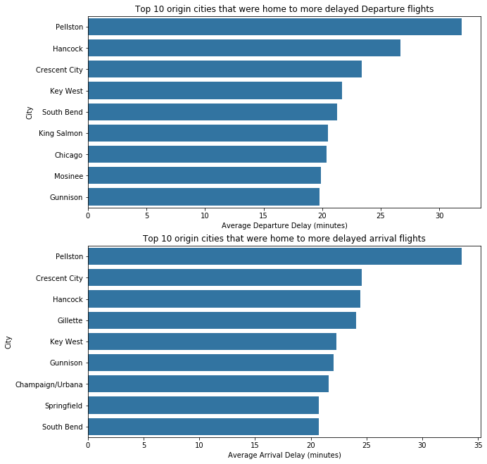

```python
mean_dep_delay = df.groupby('Origin')['DepDelay'].mean().sort_values(ascending=False)[0:9]
mean_arr_delay = df.groupby('Origin')['ArrDelay'].mean().sort_values(ascending=False)[0:9]
base_color = sb.color_palette()[0]
plt.figure(figsize=[10,11])
plt.subplot(2,1,1)
sb.barplot(y=mean_dep_delay.index, x=mean_dep_delay.values, color=base_color);
plt.title('Top 10 origin cities that were home to more delayed Departure flights')
plt.xlabel('Average Departure Delay (minutes)')
plt.ylabel('City')

plt.subplot(2,1,2)
sb.barplot(y=mean_arr_delay.index, x=mean_arr_delay.values, color=base_color);
plt.title('Top 10 origin cities that were home to more delayed arrival flights')
plt.xlabel('Average Arrival Delay (minutes)')
plt.ylabel('City');
```

## Destination Cities that are homes to more Delayed Flights

  Champaign/Urbana, Key West, Mosinee Dillingham, Newark, Chicago  
  Salem, Traverse City, San Francisco

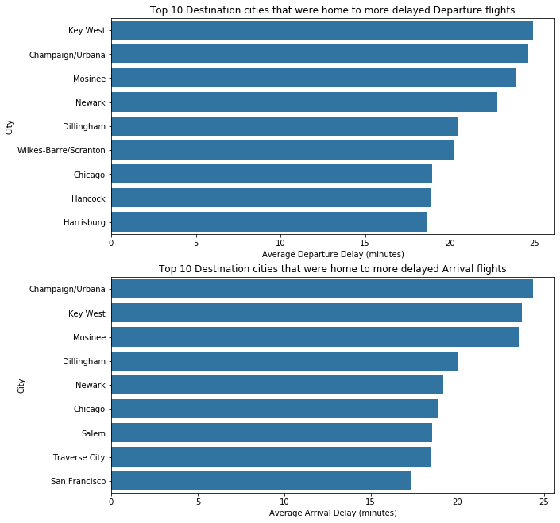

```python
mean_dep_delay = df.groupby('Dest')['DepDelay'].mean().sort_values(ascending=False)[0:9]
mean_arr_delay = df.groupby('Dest')['ArrDelay'].mean().sort_values(ascending=False)[0:9]

plt.figure(figsize=[10,11])
plt.subplot(2,1,1)
sb.barplot(y=mean_dep_delay.index, x=mean_dep_delay.values, color=base_color);
plt.title('Top 10 Destination cities that were home to more delayed Departure flights')
plt.xlabel('Average Departure Delay (minutes)')
plt.ylabel('City')

plt.subplot(2,1,2)
sb.barplot(y=mean_arr_delay.index, x=mean_arr_delay.values, color=base_color);
plt.title('Top 10 Destination cities that were home to more delayed Arrival flights')
plt.xlabel('Average Arrival Delay (minutes)')
plt.ylabel('City');
```

## Origin and Destination Cities that are homes to more Cancelled Flights

- The most 10 origin cities that were home to more cancelled flights flights were in order

  Pellston, Waterloo, Telluride  
  Hancock, Rhinelander, Kalamazoo  
  Hailey, Aspen, Dubuque
- The most 10 destination cities that were home to more cancelled flights were in order

  Pellston, Waterloo, Hancock  
  Telluride, Rhinelander, Kalamazoo Dubuque, Hailey, Saginaw

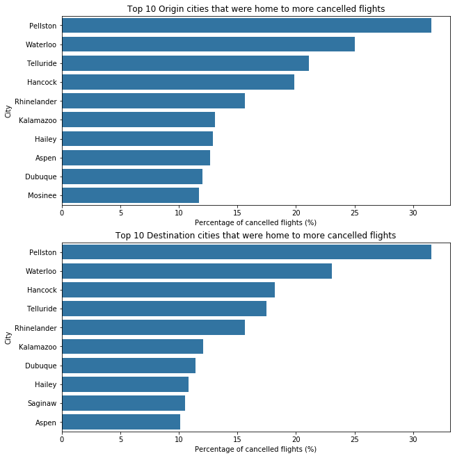

```python
origin_cancelled = df.groupby('Origin')['Cancelled'].mean().sort_values(ascending=False)[0:10]
dest_cancelled = df.groupby('Dest')['Cancelled'].mean().sort_values(ascending=False)[0:10]

plt.figure(figsize=[10,11])

plt.subplot(2,1,1)
sb.barplot(y=origin_cancelled.index, x=origin_cancelled.values*100, color=base_color);
plt.title('Top 10 Origin cities that were home to more cancelled flights')
plt.xlabel('Percentage of cancelled flights (%)')
plt.ylabel('City');

plt.subplot(2,1,2)
sb.barplot(y=dest_cancelled.index, x=dest_cancelled.values*100, color=base_color);
plt.title('Top 10 Destination cities that were home to more cancelled flights')
plt.xlabel('Percentage of cancelled flights (%)')
plt.ylabel('City');
```

## Preferred Months for Flights to occur

- February has recorded the highest average delay nearly 14 minutes delay.
- while April was the least with 8 minutes delay.

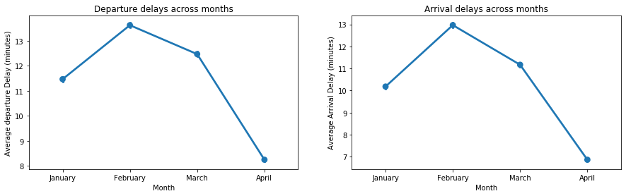

```python
plt.figure(figsize=[15,4])
plt.subplot(1,2,1)

sb.pointplot(data=df, x='Month', y='DepDelay', color=base_color);
plt.title('Departure delays across months')
plt.xlabel('Month')
plt.ylabel('Average departure Delay (minutes)');

plt.subplot(1,2,2)

sb.pointplot(data=df, x='Month', y='ArrDelay', color=base_color);
plt.title('Arrival delays across months')
plt.xlabel('Month')
plt.ylabel('Average Arrival Delay (minutes)');
```